# Sterne

I have been made aware of a very [interesting data visualization](https://www.reddit.com/r/dataisbeautiful/comments/9upux0/city_constellations_the_5_largest_cities_in_each/) : Considering places and some connection between them (i.e. roads, shortest distance as the crow flies) as stars and star constellations.

Immediately I became inspired to work at this idea with some bells and whistels, i.e. star colour, star brightness, how to draw star constellations...

The main idea of this code is as follows: Construct maps of countries with the biggest X cities, draw them as stars in the night sky, adjust brightness and size according to the population and draw star constellations with them via Minimum Spanning Trees using the distance between the cities.

I get the coordinates and population count by the *geonames*-API. I also need the borders of the country - imagine a country where every big city is in the center. Then the stars will only cover the center, but the night sky, too. This will give the wrong impression about the location of the cities. For this I get "smalles rectangles containing the country" from *opencagedata*.

```python
#Standard Imports

import math

import pandas as pd

import requests

import matplotlib.pyplot as plt
import matplotlib.lines as mlines

import networkx as nx

pd.options.display.float_format = '{:,.4f}'.format
```

```python
authorization_opencagedata =
authorization_geonames =
```

The geonames-API gives access to a wealth of information, but I find it a little bit tricky to use, see [here](http://www.geonames.org/export/geonames-search.html), since you can only filter by country-Code and not by country-Name. For this I first get every country-code available.

*PCLI* are independet countries, see [here](http://www.geonames.org/export/codes.html). Every request I send to geonames I ask for 1000 Rows, so I can sort out some clutter if necessary.

```python
columns = ["country","country_code","latitude","longitude","population"]
df_agg_countries1=pd.DataFrame(columns = columns)


#replacing at the end transforms the url from readable to one-liner
#empty search string since I just want everything PCLI
url=f"""
    http://api.geonames.org/searchJSON
        ?q=
        &featureCode=PCLI
        &maxRows=1000
        &username={authorization_geonames}
    """.replace("\n", "").replace(" ", "")

#send API request and create DataFrame with information
data = requests.get(url).json()
result = [(entry["countryName"]
           ,entry["countryCode"]
           ,entry["lat"]
           ,entry["lng"]
           ,int(entry["population"])
          ) for entry in data["geonames"]
         ]
df = pd.DataFrame(result,columns = columns)
df_agg_countries1 = df_agg_countries1.append(df)
```

```python
df_agg_countries1[:5]
```

|  | country | country_code | latitude | longitude | population |
| --- | --- | --- | --- | --- | --- |
| 0 | India | IN | 22 | 79 | 1173108018 |
| 1 | China | CN | 35 | 105 | 1330044000 |
| 2 | Austria | AT | 47.33333 | 13.33333 | 8205000 |
| 3 | Algeria | DZ | 28 | 3 | 34586184 |
| 4 | Guinea | GN | 10.83333 | -10.66667 | 10324025 |

Now I use the opencagedata to get some represantation of the borders. Note that this could also be done with shape files for the actual borders, but I think this is good enough. It fails for countries with remote exclaves, though, since the rectangle also has to contain all the colonies. This means that the actual plot for e.g. the netherlands has the cities of the mainland all bunched in a very small area in a big night sky.

```python
columns = ["country"
           ,"bound_northeast_latitude"
           ,"bound_northeast_longitude"
           ,"bound_southwest_latitude"
           ,"bound_southwest_longitude"
          ]
df_agg_countries2=pd.DataFrame(columns = columns)

for i, country in enumerate(df_agg_countries1.country):

    print(f"Get data for country {i+1}/{len(df_agg_countries1.country)} : {country}                        ", end = "\r")

    #replacing at the end transforms the url from readable to one-liner
    #note that the query has to contain "+" instead of white spaces, since the query is in the url, which cannot contain whitespaces
    #set language "en" so it searches for the english words as received by the geonames-API
    url=f"""
        https://api.opencagedata.com/geocode/v1/json?
            key={authorization_opencagedata}
            &q={country.replace(" ","+")}
            &language=en
            &no_annotations=1
        """.replace("\n", "").replace(" ", "")

    #send API request and create DataFrame with information
    data = requests.get(url).json()

    if data["total_results"] != 0:
        #[0] => get most relevant search result
        bound_northeast_latitude = data["results"][0]["bounds"]["northeast"]["lat"]
        bound_northeast_longitude = data["results"][0]["bounds"]["northeast"]["lng"]
        bound_southwest_latitude = data["results"][0]["bounds"]["southwest"]["lat"]
        bound_southwest_longitude = data["results"][0]["bounds"]["southwest"]["lng"]

        tupel = (country
                 ,bound_northeast_latitude
                 ,bound_northeast_longitude
                 ,bound_southwest_latitude
                 ,bound_southwest_longitude
                )
        df = pd.DataFrame([tupel],columns = columns)
        df_agg_countries2 = df_agg_countries2.append(df)
    else:
        print("\n\t Not Found!")
```

```
Get data for country 193/193 : Monaco
```

```python
df_agg_countries = df_agg_countries1.merge(df_agg_countries2, on = "country")
df_agg_countries[:5]
```

|  | country | country_code | latitude | longitude | population | bound_northeast_latitude | bound_northeast_longitude | bound_southwest_latitude | bound_southwest_longitude |
| --- | --- | --- | --- | --- | --- | --- | --- | --- | --- |
| 0 | India | IN | 22 | 79 | 1173108018 | 35.6745 | 97.3956 | 6.5546 | 68.1114 |
| 1 | China | CN | 35 | 105 | 1330044000 | 53.5608 | 134.7755 | 8.8383 | 73.4997 |
| 2 | Austria | AT | 47.33333 | 13.33333 | 8205000 | 49.0205 | 17.1608 | 46.3723 | 9.5307 |
| 3 | Algeria | DZ | 28 | 3 | 34586184 | 37.2962 | 11.9973 | 18.9681 | -8.6689 |
| 4 | Guinea | GN | 10.83333 | -10.66667 | 10324025 | 12.6756 | -7.6382 | 7.1906 | -15.5681 |

# Cities

Now that I have the country informations as needed, I can query the geonames-API for the cities. Note that I can only filter by country-code, not by country-name (the search parameter is still called *country*, though. I of course can also filter after getting the results, but there is the possibility that the results are so bad that the 1000 rows are wittled down to not enough rows for a meaningfull visualization. Search results can get bad if the search engine thinks that it is a relevant result from the literal query, but this is not true for the query as meant, e.g. Searching for Italy and getting cities in the USA with a district named Little Italy back. I understand why this is returned, but I don't want it.

Featureclass *P* means only "places of people", i.e. cities, districs... FeatureCode *PLX* are districts. I only want the whole city, so I filter it. See [here](http://www.geonames.org/export/codes.html).

```python
columns = ["city","country","latitude","longitude","population"]
df_agg_cities=pd.DataFrame(columns = columns)

for i,country_code in enumerate(df_agg_countries.country_code):

    print(f"Get data for country_code {i+1}/{len(df_agg_countries.country_code)} : {country_code}                        ", end = "\r")

    #replacing at the end transforms the url from readable to one-liner
    #empty search string since I want every result of a P in the country_code
    url=f"""
        http://api.geonames.org/searchJSON
            ?q=
            &featureClass=P
            &country={country_code}
            &maxRows=1000
            &orderby=population
            &username={authorization_geonames}
        """.replace("\n", "").replace(" ", "")

    #send API request and create DataFrame with information
    data = requests.get(url).json()
    result = [(entry["toponymName"]
               ,entry["countryName"]
               ,float(entry["lat"])
               ,float(entry["lng"])
               ,float(entry["population"])
              ) for entry in data["geonames"]
                  if entry.get("fcode") != "PPLX"
             ]
    df = pd.DataFrame(result, columns = columns)
    df_agg_cities = df_agg_cities.append(df)
```

```
Get data for country_code 193/193 : MC
```

```python
result
```

```
[('Monaco', 'Monaco', 43.73333, 7.41667, 32965.0)]
```

Now to the actual plotting. I first start with an easier version.

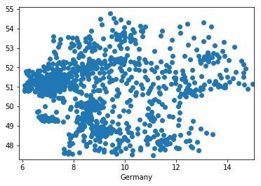

```python
#get cities of the country and a lookup for the country information
df_cities = df_agg_cities.query("country == 'Germany'")
dict_country = df_agg_countries.query("country == 'Germany'").to_dict("records")[0]


ax = plt.axes()
#set the borders of the plot to the "borders" of the country. Not that this is not necessarily square
ax.set_xlim(dict_country["bound_southwest_longitude"],dict_country["bound_northeast_longitude"])
ax.set_ylim(dict_country["bound_southwest_latitude"],dict_country["bound_northeast_latitude"])
ax.set_xlabel("Germany")

ax.scatter(df_cities.longitude,df_cities.latitude)
```

Looks promising! I now add the "night-Sky-feeling". I do this by a dictionary to be more flexible, one could also do this with a configuration file. I got the star colour from here and the night sky colour from here.

Note that matplotlib expects RGB-Colours as 3-tuple of values from 0 to 1.

Also the picture is a little bit too "dense".

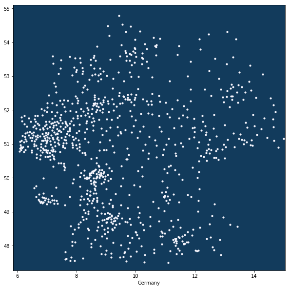

```python
reference_colours = dict()
reference_colours[("sky","red")] =    0.07
reference_colours[("sky","green")] =  0.23
reference_colours[("sky","blue")] =  0.36
reference_colours[("star","red")] =  248/255
reference_colours[("star","green")] =  247/255
reference_colours[("star","blue")] =  255/255

#get cities of the country and a lookup for the country information
df_cities = df_agg_cities.query("country == 'Germany'")
dict_country = df_agg_countries.query("country == 'Germany'").to_dict("records")[0]

figure = plt.figure(figsize=(10,10))
ax = figure.add_subplot(111)
#set the borders of the plot to the "borders" of the country. Not that this is not necessarily square
ax.set_xlim(dict_country["bound_southwest_longitude"],dict_country["bound_northeast_longitude"])
ax.set_ylim(dict_country["bound_southwest_latitude"],dict_country["bound_northeast_latitude"])
ax.set_xlabel("Germany")


ax.set_facecolor((reference_colours[("sky","red")]
                  , reference_colours[("sky","green")]
                  , reference_colours[("sky","blue")]
                 ))
colour = (reference_colours[("star","red")],reference_colours[("star","green")],reference_colours[("star","blue")])

ax.scatter(df_cities.longitude,df_cities.latitude, c = colour, s = 10)
```

Homely! The next step would be to add size and brightness according to the city population.

Size: I simply define a size for the biggest city and then scale accordingly.

Brightness: When is a star "not bright"? When it is the same colour as the night sky. So I consider the continuum of colours "between" night sky and stars. If a city is 30% as big as the biggest city, then it gets the colour 30% the way from night sky to star. So

city_colour = colour_night_sky + ratio_population_count * (colour_star - colour_night_sky)

I am not fully satisfied with the brightness approach, but it is good enough.

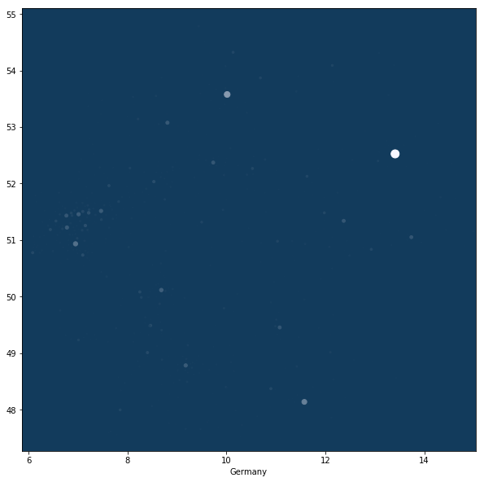

```python
reference_colours = dict()
reference_colours[("sky","red")] =    0.07
reference_colours[("sky","green")] =  0.23
reference_colours[("sky","blue")] =  0.36
reference_colours[("star","red")] =  248/255
reference_colours[("star","green")] =  247/255
reference_colours[("star","blue")] =  255/255

#get cities of the country and a lookup for the country information. Copy since I add columns to the slice
df_cities = df_agg_cities.query("country == 'Germany'").copy()
dict_country = df_agg_countries.query("country == 'Germany'").to_dict("records")[0]

#defince city colour and size
df_cities["fraction"] = df_cities.population / dict_country["population"]
df_cities["fraction_normalized"] = df_cities.fraction / df_cities.fraction.max()

for colour in ["red","green","blue"]:
    colour_sky = reference_colours[("sky",colour)]
    colour_star = reference_colours[("star",colour)]
    df_cities[f"rgb_{colour}"] = colour_sky + df_cities.fraction_normalized  * (colour_star - colour_sky )

figure = plt.figure(figsize=(10,10))
ax = figure.add_subplot(111)
#set the borders of the plot to the "borders" of the country. Not that this is not necessarily square
ax.set_xlim(dict_country["bound_southwest_longitude"],dict_country["bound_northeast_longitude"])
ax.set_ylim(dict_country["bound_southwest_latitude"],dict_country["bound_northeast_latitude"])
ax.set_xlabel("Germany")


#colours
ax.set_facecolor((reference_colours[("sky","red")]
                  , reference_colours[("sky","green")]
                  , reference_colours[("sky","blue")]
                 ))
colours = [(entry["rgb_red"],entry["rgb_green"],entry["rgb_blue"]) for entry in df_cities.to_dict("records") ]

#sizes
sizes = 100 * df_cities.fraction_normalized

#draw
ax.scatter(df_cities.longitude,df_cities.latitude, c = colours, s = sizes)
```

The dropoff in the size and brightness is too big. In many countries this would be even worse: consider France where the 2nd largest city already has only a third of the population of the biggest city, i.e. Lyon will only be a third as bright and big as Paris.

For this I introduce scaling functions, e.g. taking the n-th root of the ratio (square root: 0.81 -> 0.9, 0.36 -> 0.6).

I also represent the citys by literal stars instead of circles.

Note the sorting of the cities: I want small cities to be drawn first, so brighter cities that are roughly at the same location are drawn over them.

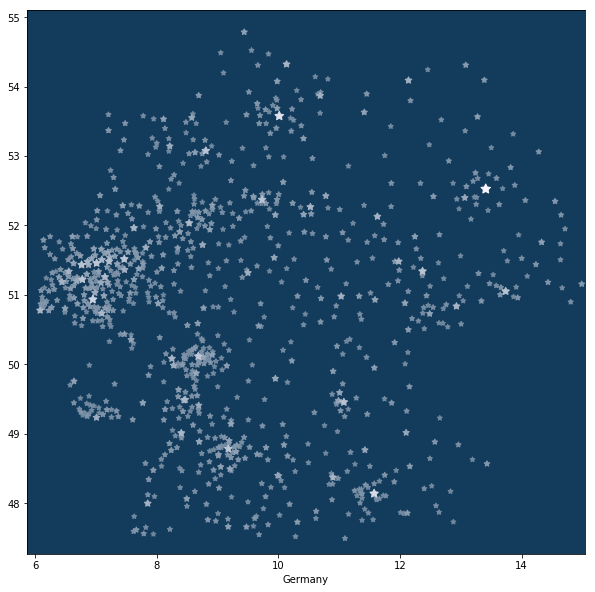

```python
#configuration
reference_colours = dict()
reference_colours[("sky","red")] =    0.07
reference_colours[("sky","green")] =  0.23
reference_colours[("sky","blue")] =  0.36
reference_colours[("star","red")] =  248/255
reference_colours[("star","green")] =  247/255
reference_colours[("star","blue")] =  255/255

scaling_function_colour = lambda x: x ** (1/6)
scaling_function_size = lambda x: x ** (1/4)

#get cities of the country and a lookup for the country information. Copy() since I add columns to the slice
df_cities = df_agg_cities.query("country == 'Germany'").copy().sort_values(by = "population")
dict_country = df_agg_countries.query("country == 'Germany'").to_dict("records")[0]

#defince city colour and size
df_cities["fraction"] = df_cities.population / dict_country["population"]
df_cities["fraction_normalized"] = df_cities.fraction / df_cities.fraction.max()

for colour in ["red","green","blue"]:
    colour_sky = reference_colours[("sky",colour)]
    colour_star = reference_colours[("star",colour)]
    df_cities[f"rgb_{colour}"] = colour_sky + df_cities.fraction_normalized.map(scaling_function_colour)  * (colour_star - colour_sky )

figure = plt.figure(figsize=(10,10))
ax = figure.add_subplot(111)
#set the borders of the plot to the "borders" of the country. Not that this is not necessarily square
ax.set_xlim(dict_country["bound_southwest_longitude"],dict_country["bound_northeast_longitude"])
ax.set_ylim(dict_country["bound_southwest_latitude"],dict_country["bound_northeast_latitude"])
ax.set_xlabel("Germany")

#colours
ax.set_facecolor((reference_colours[("sky","red")]
                  , reference_colours[("sky","green")]
                  , reference_colours[("sky","blue")]
                 ))
colours = [(entry["rgb_red"],entry["rgb_green"],entry["rgb_blue"]) for entry in df_cities.to_dict("records") ]

#sizes
sizes = 100 * df_cities.fraction_normalized.map(scaling_function_size)

#draw
ax.scatter(df_cities.longitude,df_cities.latitude, c = colours, s = sizes, marker = (5,1,0))
```

The stars are nice. Now onto the star constellations: A first approach would be Minimum Spanning Trees of the complete graph on the vertices. They can be fastly computed and are planar, not too sparse and not too crowded.

```python
def get_minimum_spanning_tree(df_cities):
    df = df_cities.copy()
    df["cross_join_key"] = 1
    # < means that an unordered pair of cities is only considered once and only if the cities are not the same, i.e.
    #I will not consider a pair (City1,City1) and I will not consider the pair (City2,City1) if I already consider (City1,City2)
    df2 = df.merge(df, on = ["cross_join_key"]) \
                .query("city_x < city_y") \
                .drop("cross_join_key", axis = 1)

    #euclidian distance of the coordinates
    df2["distance_squared"] = (df2.latitude_x - df2.latitude_y) ** 2  + (df2.longitude_x - df2.longitude_y) ** 2

    #build the complete graph
    G = nx.Graph()
    for entry in df2.to_dict("records"):
        G.add_edge(entry["city_x"], entry["city_y"], weight = entry["distance_squared"])

    #build the MST. Since the input is a complete graph, every possible way of drawing will be considered
    minimum_spanning_tree = nx.minimum_spanning_tree(G)

    #transform to DataFrame with coordinates
    df_mst = pd.DataFrame([edge for edge in minimum_spanning_tree.edges],columns = ["city_x","city_y"])
    df_mst2 = df_mst.merge(df2, on = ["city_x","city_y"])
    df_mst2 = df_mst2[["city_x","latitude_x","longitude_x","city_y","latitude_y","longitude_y"]]
    return df_mst2
```

Note the join on the city name. This means I have to delete duplicate city names, I will take the one with the biggest population.

I also add a filter how many citys will be displayed - the biggest *count_cities* cities.

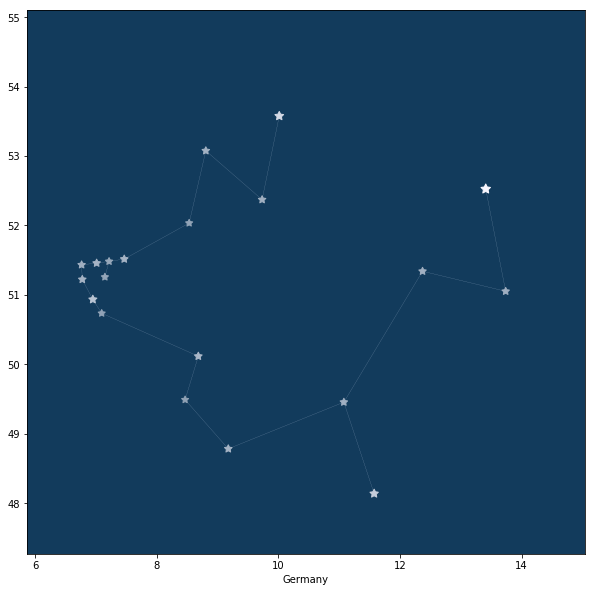

```python
#configuration
reference_colours = dict()
reference_colours[("sky","red")] =    0.07
reference_colours[("sky","green")] =  0.23
reference_colours[("sky","blue")] =  0.36
reference_colours[("star","red")] =  248/255
reference_colours[("star","green")] =  247/255
reference_colours[("star","blue")] =  255/255
colours_line = (0.5,0.6,0.7)
count_cities = 20

scaling_function_colour = lambda x: x ** (1/6)
scaling_function_size = lambda x: x ** (1/4)

#get cities of the country and a lookup for the country information
df_cities = df_agg_cities \
                    .query("country == 'Germany'") \
                    .sort_values(by = "population", ascending = False) \
                    [:count_cities] \
                    .groupby(["city"]) \
                    [df_agg_cities.drop("city", axis = 1).columns].first() \

#I am not sure why I couldn't append it to the command before, but the compiler didn't understand my line continuation
df_cities = df_cities.reset_index().sort_values(by = "population")
dict_country = df_agg_countries.query("country == 'Germany'").to_dict("records")[0]

#defince city colour and size
df_cities["fraction"] = df_cities.population / dict_country["population"]
df_cities["fraction_normalized"] = df_cities.fraction / df_cities.fraction.max()

for colour in ["red","green","blue"]:
    colour_sky = reference_colours[("sky",colour)]
    colour_star = reference_colours[("star",colour)]
    df_cities[f"rgb_{colour}"] = colour_sky + df_cities.fraction_normalized.map(scaling_function_size)  * (colour_star - colour_sky)

figure = plt.figure(figsize=(10,10))
ax = figure.add_subplot(111)
#set the borders of the plot to the "borders" of the country. Not that this is not necessarily square
ax.set_xlim(dict_country["bound_southwest_longitude"],dict_country["bound_northeast_longitude"])
ax.set_ylim(dict_country["bound_southwest_latitude"],dict_country["bound_northeast_latitude"])
ax.set_xlabel("Germany")


#colours
ax.set_facecolor((reference_colours[("sky","red")]
                  , reference_colours[("sky","green")]
                  , reference_colours[("sky","blue")]
                 ))
colours = [(entry["rgb_red"],entry["rgb_green"],entry["rgb_blue"]) for entry in df_cities.to_dict("records") ]

#sizes
sizes = 100 * df_cities.fraction_normalized.map(scaling_function_size)

#draw the stars
ax.scatter(df_cities.longitude,df_cities.latitude, c = colours, s = sizes, marker = (5,1,0), zorder = 2)

#draw the lines of the MST
df_mst = get_minimum_spanning_Tree(df_cities)
for edge in df_mst.to_dict("records"):
    point_1=(edge["longitude_x"],edge["latitude_x"])
    point_2=(edge["longitude_y"],edge["latitude_y"])
    ax.plot((point_1[0],point_2[0]),(point_1[1],point_2[1]), color = ((0.5,0.6,0.7)), linewidth = 0.2, zorder = 1)
```

Nice. Now a loop for some countries.

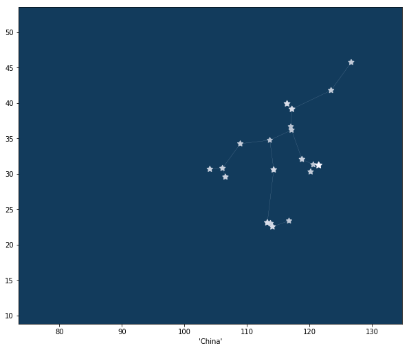

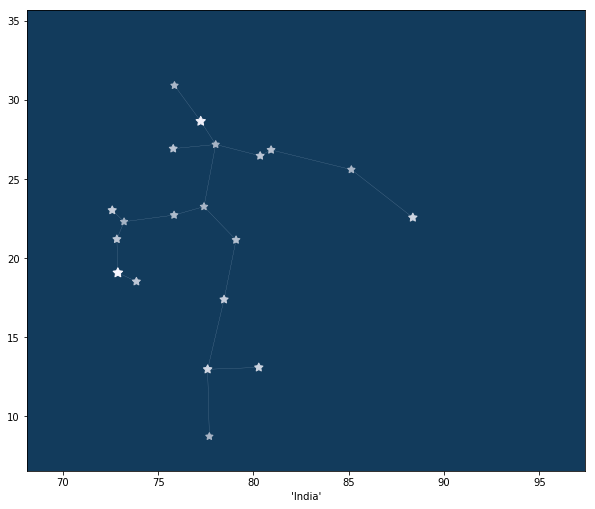

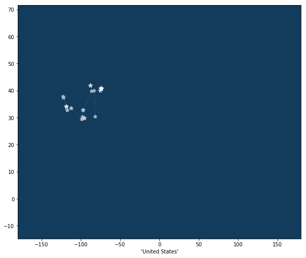

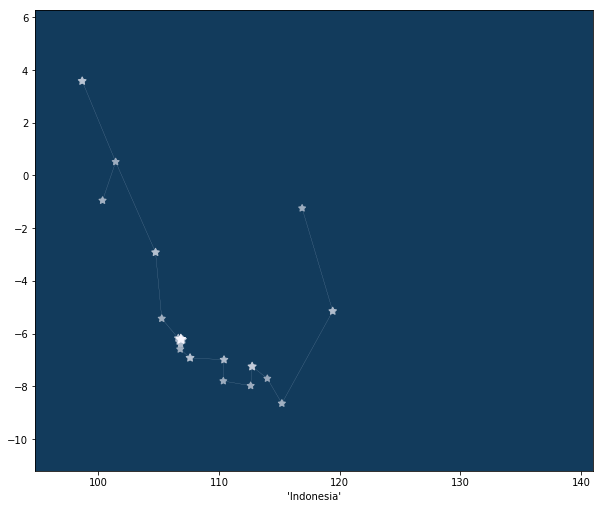

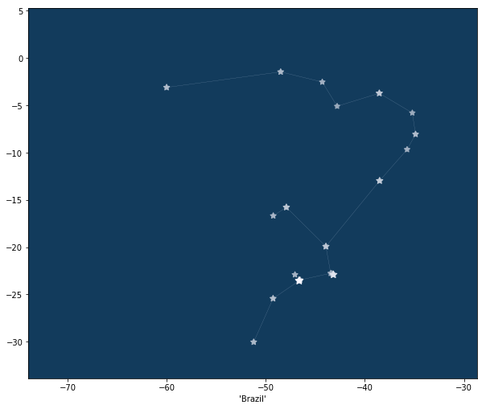

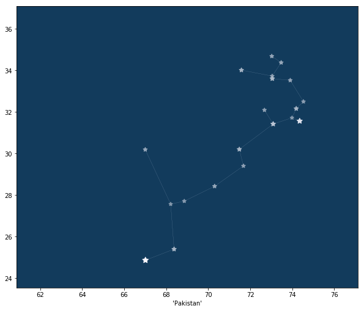

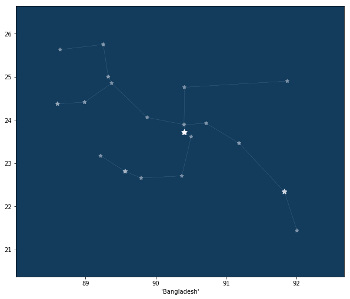

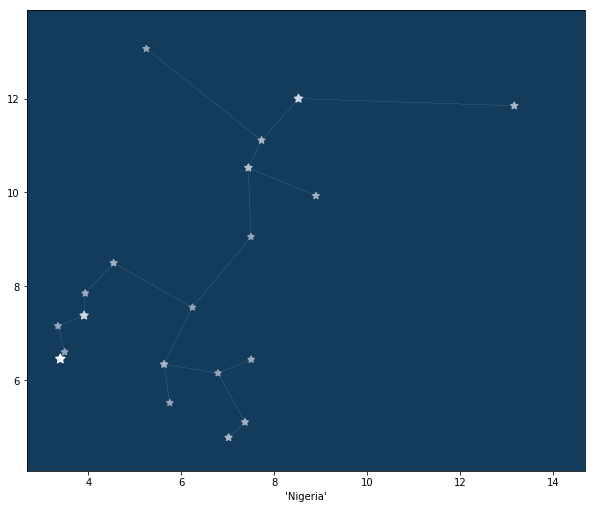

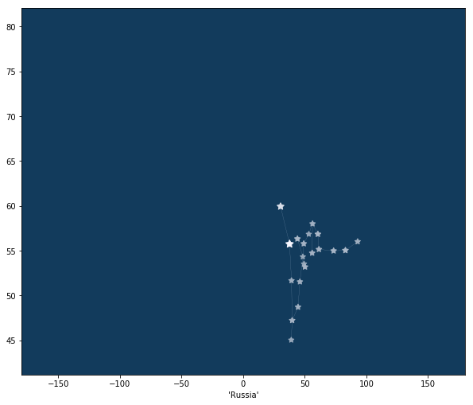

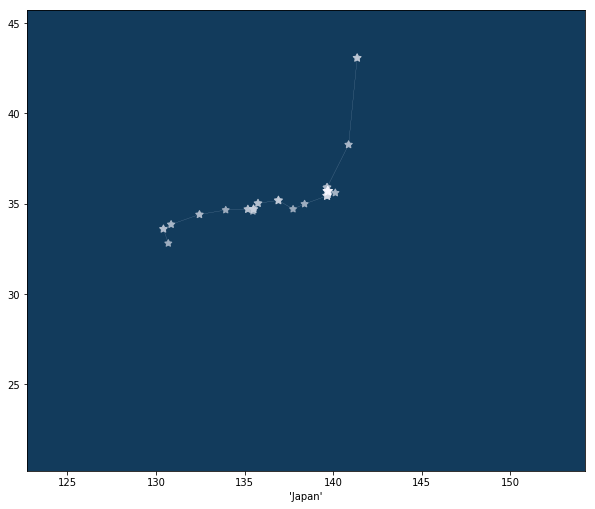

```python
#configuration
reference_colours = dict()
reference_colours[("sky","red")] =    0.07
reference_colours[("sky","green")] =  0.23
reference_colours[("sky","blue")] =  0.36
reference_colours[("star","red")] =  248/255
reference_colours[("star","green")] =  247/255
reference_colours[("star","blue")] =  255/255
colours_line = (0.5,0.6,0.7)
count_cities = 20
count_contries = 10
scaling_function_colour = lambda x: x ** (1/6)
scaling_function_size = lambda x: x ** (1/4)



for i,country in enumerate(df_agg_countries1.sort_values(by = ["population"], ascending = False)[:count_contries].country):

    #get cities of the country and a lookup for the country information
    df_cities = df_agg_cities \
                    .query(f"country == '{country}'") \
                    .sort_values(by = "population", ascending = False) \
                    [:count_cities] \
                    .groupby(["city"]) \
                    [df_agg_cities.drop("city", axis = 1).columns].first() \

    #I am not sure why I couldn't append it to the command before, but the compiler didn't understand my line continuation
    df_cities = df_cities.reset_index().sort_values(by = "population")
    dict_country = df_agg_countries.query(f"country == '{country}'").to_dict("records")[0]

    df_cities["fraction"] = df_cities.population / dict_country["population"]
    df_cities["fraction_normalized"] = df_cities.fraction / df_cities.fraction.max()

    for colour in ["red","green","blue"]:
        colour_sky = reference_colours[("sky",colour)]
        colour_star = reference_colours[("star",colour)]
        df_cities[f"rgb_{colour}"] = min(colour_sky,colour_star)  \
                                          + df_cities.fraction_normalized ** (1/5) * abs(colour_sky - colour_star)


    figure = plt.figure(figsize=(10, 10 * count_contries))
    ax = figure.add_subplot(count_contries, 1, i+1)
    #set the borders of the plot to the "borders" of the country. Not that this is not necessarily square
    ax.set_xlim(dict_country["bound_southwest_longitude"],dict_country["bound_northeast_longitude"])
    ax.set_ylim(dict_country["bound_southwest_latitude"],dict_country["bound_northeast_latitude"])
    ax.set_xlabel(f"'{country}'")


    #colours
    ax.set_facecolor((reference_colours[("sky","red")]
                      , reference_colours[("sky","green")]
                      , reference_colours[("sky","blue")]
                     ))
    colours = [(entry["rgb_red"],entry["rgb_green"],entry["rgb_blue"]) for entry in df_cities.to_dict("records") ]

    #sizes
    sizes = 100 * df_cities.fraction_normalized.map(scaling_function_size)


    #draw the stars
    ax.scatter(df_cities.longitude,df_cities.latitude, c = colours, s = sizes, marker = (5,1,0), zorder = 2)
    #draw the lines of the MST
    df_mst = get_minimum_spanning_Tree(df_cities)
    for edge in df_mst.to_dict("records"):
        point_1=(edge["longitude_x"],edge["latitude_x"])
        point_2=(edge["longitude_y"],edge["latitude_y"])
        ax.plot((point_1[0],point_2[0]),(point_1[1],point_2[1]), color = ((0.5,0.6,0.7)), linewidth = 0.2, zorder = 1)
```

For every country I will define an individual rectangle contained in a square. The square defines the maximum size of the plot, the rectangle the actual size.

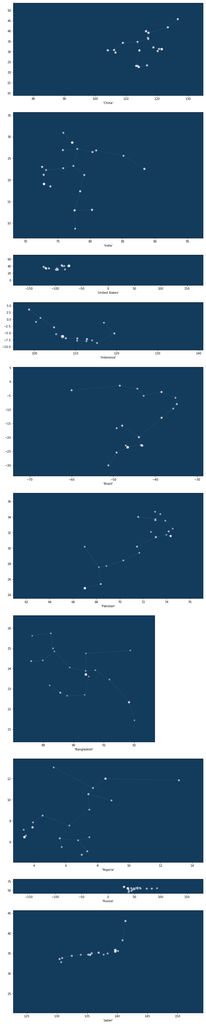

```python
#configuration
reference_colours = dict()
reference_colours[("sky","red")] =    0.07
reference_colours[("sky","green")] =  0.23
reference_colours[("sky","blue")] =  0.36
reference_colours[("star","red")] =  248/255
reference_colours[("star","green")] =  247/255
reference_colours[("star","blue")] =  255/255
colours_line = (0.5,0.6,0.7)
count_cities = 20
count_contries = 10
scaling_function_colour = lambda x: x ** (1/6)
scaling_function_size = lambda x: x ** (1/4)
max_width = 1.5
max_height = 1.5
end_of_rectangle = 0

for i,country in enumerate(df_agg_countries1.sort_values(by = ["population"], ascending = False)[:count_contries].country):


    #get cities of the country and a lookup for the country information
    df_cities = df_agg_cities \
                    .query(f"country == '{country}'") \
                    .sort_values(by = "population", ascending = False) \
                    [:count_cities] \
                    .groupby(["city"]) \
                    [df_agg_cities.drop("city", axis = 1).columns].first() \

    #I am not sure why I couldn't append it to the command before, but the compiler didn't understand my line continuation
    df_cities = df_cities.reset_index().sort_values(by = "population")
    dict_country = df_agg_countries.query(f"country == '{country}'").to_dict("records")[0]

    df_cities["fraction"] = df_cities.population / dict_country["population"]
    df_cities["fraction_normalized"] = df_cities.fraction / df_cities.fraction.max()

    for colour in ["red","green","blue"]:
        colour_sky = reference_colours[("sky",colour)]
        colour_star = reference_colours[("star",colour)]
        df_cities[f"rgb_{colour}"] = min(colour_sky,colour_star)  \
                                          + df_cities.fraction_normalized ** (1/5) * abs(colour_sky - colour_star)




    #define the indivudual rectangle: First measure the country, then decide if it is a "tall" or a "wide" rectangle.
    #"Tall" rectangles are as tall as the containing square, "wide" rectangles are as wide as the containing square. The other dimension is then scaled
    country_width = dict_country["bound_northeast_longitude"] - dict_country["bound_southwest_longitude"]
    country_height = dict_country["bound_northeast_latitude"] - dict_country["bound_southwest_latitude"]

    scaled_width = 0
    scaled_height = 0

    if ( country_width <= country_height): #longer than tall
        scaled_height = max_height
        scaled_width = max_width * country_width / country_height
    else: #taller then long
        scaled_width = max_width
        scaled_height = max_height * country_height / country_width

    #If the rectangle is wide, there might be a lot of whitespace between the actual plots. For this I remember where the last _rectangle_, not square, ended
    end_of_rectangle = end_of_rectangle + scaled_height + 0.2
    rectangle = [0, - 1 * end_of_rectangle,scaled_width,scaled_height]


    ax = plt.axes(rectangle)

    #set the borders of the plot to the "borders" of the country. Not that this is not necessarily square
    ax.set_xlim(dict_country["bound_southwest_longitude"],dict_country["bound_northeast_longitude"])
    ax.set_ylim(dict_country["bound_southwest_latitude"],dict_country["bound_northeast_latitude"])
    ax.set_xlabel(f"'{country}'")


    #colours
    ax.set_facecolor((reference_colours[("sky","red")]
                      , reference_colours[("sky","green")]
                      , reference_colours[("sky","blue")]
                     ))
    colours = [(entry["rgb_red"],entry["rgb_green"],entry["rgb_blue"]) for entry in df_cities.to_dict("records") ]

    #sizes
    sizes = 100 * df_cities.fraction_normalized.map(scaling_function_size)


    #draw the stars
    ax.scatter(df_cities.longitude,df_cities.latitude, c = colours, s = sizes, marker = (5,1,0), zorder = 2)
    #draw the lines of the MST
    df_mst = get_minimum_spanning_Tree(df_cities)
    for edge in df_mst.to_dict("records"):
        point_1=(edge["longitude_x"],edge["latitude_x"])
        point_2=(edge["longitude_y"],edge["latitude_y"])
        ax.plot((point_1[0],point_2[0]),(point_1[1],point_2[1]), color = ((0.5,0.6,0.7)), linewidth = 0.2, zorder = 1)
```

**Much** better. I still have a problem with "colonies" (see USA) and countries having high negative and high positive longitude (see Russia), but it is good enough for me now.

Top 100 countries:

```python
#configuration
reference_colours = dict()
reference_colours[("sky","red")] =    0.07
reference_colours[("sky","green")] =  0.23
reference_colours[("sky","blue")] =  0.36
reference_colours[("star","red")] =  248/255
reference_colours[("star","green")] =  247/255
reference_colours[("star","blue")] =  255/255
colours_line = (0.5,0.6,0.7)
count_cities = 20
count_countries = 100
scaling_function_colour = lambda x: x ** (1/6)
scaling_function_size = lambda x: x ** (1/4)
max_width = 1.5
max_height = 1.5
end_of_rectangle = 0

for i,country in enumerate(df_agg_countries1.sort_values(by = ["population"], ascending = False).country[:count_countries]):


    #get cities of the country and a lookup for the country information
    df_cities = df_agg_cities \
                    .query(f"country == '{country}'") \
                    .sort_values(by = "population", ascending = False) \
                    [:count_cities] \
                    .groupby(["city"]) \
                    [df_agg_cities.drop("city", axis = 1).columns].first() \

    #I am not sure why I couldn't append it to the command before, but the compiler didn't understand my line continuation
    df_cities = df_cities.reset_index().sort_values(by = "population")
    dict_country = df_agg_countries.query(f"country == '{country}'").to_dict("records")[0]

    df_cities["fraction"] = df_cities.population / dict_country["population"]
    df_cities["fraction_normalized"] = df_cities.fraction / df_cities.fraction.max()

    for colour in ["red","green","blue"]:
        colour_sky = reference_colours[("sky",colour)]
        colour_star = reference_colours[("star",colour)]
        df_cities[f"rgb_{colour}"] = min(colour_sky,colour_star)  \
                                          + df_cities.fraction_normalized ** (1/5) * abs(colour_sky - colour_star)




    #define the indivudual rectangle: First measure the country, then decide if it is a "tall" or a "wide" rectangle.
    #"Tall" rectangles are as tall as the containing square, "wide" rectangles are as wide as the containing square. The other dimension is then scaled
    country_width = dict_country["bound_northeast_longitude"] - dict_country["bound_southwest_longitude"]
    country_height = dict_country["bound_northeast_latitude"] - dict_country["bound_southwest_latitude"]

    scaled_width = 0
    scaled_height = 0

    if ( country_width <= country_height): #longer than tall
        scaled_height = max_height
        scaled_width = max_width * country_width / country_height
    else: #taller then long
        scaled_width = max_width
        scaled_height = max_height * country_height / country_width

    #If the rectangle is wide, there might be a lot of whitespace between the actual plots. For this I remember where the last _rectangle_, not square, ended
    end_of_rectangle = end_of_rectangle + scaled_height + 0.2
    rectangle = [0, - 1 * end_of_rectangle,scaled_width,scaled_height]


    ax = plt.axes(rectangle)

    #set the borders of the plot to the "borders" of the country. Not that this is not necessarily square
    ax.set_xlim(dict_country["bound_southwest_longitude"],dict_country["bound_northeast_longitude"])
    ax.set_ylim(dict_country["bound_southwest_latitude"],dict_country["bound_northeast_latitude"])
    ax.set_xlabel(f"'{country}'")


    #colours
    ax.set_facecolor((reference_colours[("sky","red")]
                      , reference_colours[("sky","green")]
                      , reference_colours[("sky","blue")]
                     ))
    colours = [(entry["rgb_red"],entry["rgb_green"],entry["rgb_blue"]) for entry in df_cities.to_dict("records") ]

    #sizes
    sizes = 100 * df_cities.fraction_normalized.map(scaling_function_size)


    #draw the stars
    ax.scatter(df_cities.longitude,df_cities.latitude, c = colours, s = sizes, marker = (5,1,0), zorder = 2)
    #draw the lines of the MST
    df_mst = get_minimum_spanning_Tree(df_cities)
    for edge in df_mst.to_dict("records"):
        point_1=(edge["longitude_x"],edge["latitude_x"])
        point_2=(edge["longitude_y"],edge["latitude_y"])
        ax.plot((point_1[0],point_2[0]),(point_1[1],point_2[1]), color = ((0.5,0.6,0.7)), linewidth = 0.2, zorder = 1)
```

[figure not shown]

Here we have it.

Additional work that could be done:

- star constellations are not MSTs, e.g. [here](https://en.wikipedia.org/wiki/Ursa_Minor) or [here](https://en.wikipedia.org/wiki/Ursa_Major). I think one could get better visuals by choosing a random connected planar graph, but this is computationally *much* more expensive (idea: construct every graph possible, check for connectedness, check for planarity)
- there are some mismatches between the borders and the countries: Mexicos borders are to small, USAs & Netherlands borders are much too wide(since I am only interested in the mainland). The mismatches stem from the fact that two different data sources are used.
- the colouring could be improved. What does it mean for a star to be sparkling?